# Investigating Politics

January 31, 2018

## Causal Logics

## Causal Theory

A **causal theory** identifies **systematic** causes that operate across space and time

- It is a kind of **general** knowledge
- **Patterns** within complexity
- Helps to **predict**
- Helps explain **specific** event

## An example:

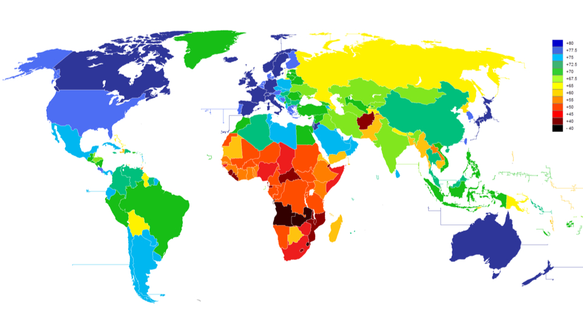

## Patterns?

### Democracies appear to have better health

- Better life expectancy
- Lower infant/maternal mortality

## Democracy and health

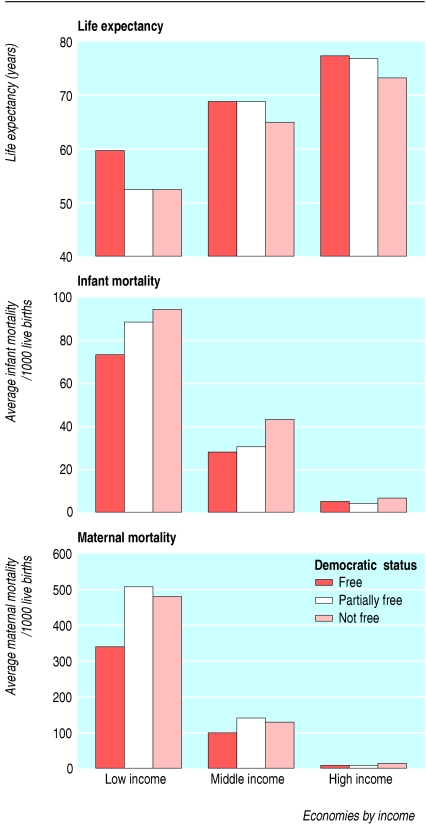

## What explains this pattern?

### Why does more democracy improve health?

## Answering "why"

### More democracy \(\xrightarrow{}\)

Voting can remove a government \(\xrightarrow{}\)

Government officials need to appease large electorate to keep office \(\xrightarrow{}\)

Governments must spend more on improving citizen health \(\xrightarrow{}\)

### Better health for citizens

### A *Causal Logic* (Mechanisms)

## Causal Logic

### A *causal logic*:

A set of statements about **how** or **why** a cause produces its effect.

## Causal Logic

### Details

Given a claim \(C \xrightarrow{} E\):

- Causal logic given a **causal chain** that logically connects cause to the effect
- \(C \xrightarrow{} e_1 \xrightarrow{} e_2 \xrightarrow{} e_3 \xrightarrow{} E\)

Makes additional assumptions/assertions:

- Need to believe additional causal claims about each step in the logic
- E.g.: do we believe this story if we don't accept \(e_2 \xrightarrow{} e_3\)

## Making a causal logic

1. Must start with **cause**, end with the **effect**
2. Each step is logically related to the next through a **causal** relationship
3. It is **not** a chronological list of specific events. It is a **general** sequence through which one things causes another

## Democracy and Health

**More democracy** \(\xrightarrow{}\)

Voting can remove a government \(\xrightarrow{\mathbf{?}}\)

Government officials need to appease large electorate to keep office \(\xrightarrow{}\)

Governments must spend more on improving citizen health \(\xrightarrow{}\)

**Better health for citizens**

### For "?" step to work, assume that:

- Politicians motivated to stay in office
  - Would this step work if politicians did not care?

## Democracy and Health

**More democracy** \(\xrightarrow{}\)

Voting can remove a government \(\xrightarrow{}\)

Government officials need to appease large electorate to keep office \(\xrightarrow{\mathbf{?}}\)

Governments must spend more on improving citizen health \(\xrightarrow{}\)

**Better health for citizens**

### For "?" step to work, assume that:

- Votes are cast based on health policy/outcomes
  - Would this step work if votes based on shared ethnicity? Best ads?

## Democracy and Health

**More democracy** \(\xrightarrow{\mathbf{?}}\)

Voting can remove a government \(\xrightarrow{}\)

Government officials need to appease large electorate to keep office \(\xrightarrow{}\)

Governments must spend more on improving citizen health \(\xrightarrow{}\)

**Better health for citizens**

### For "?" step to work, assume that:

- Governments only changed by voting
  - would this step work if authoritarian governments can be removed by revolution/mass protest?

## What goes into a Causal Logic?

Focus on actors/agents

### How do actors make choices?

- What are actors' goals?
- What incentives do they have?
- What resources do they lack/possess?
- What rules/institutions must they work within?
- What cultural norms do they follow?

### How do actors form attitudes/beliefs/goals?

- Cognitive mechanisms
- Emotional processes
- What information do they have?

### How do organizations/collective groups "behave"

## Competing Causal Logics

Wealthy countries are less likely to experience civil war. Why?

### Three different logics

1. Wealth \(\xrightarrow{}\) Larger defense budget \(\xrightarrow{}\) Rivals deterred \(\xrightarrow{}\) Less civil war
2. Wealth \(\xrightarrow{}\) Higher standard of living \(\xrightarrow{}\) Fewer grievances \(\xrightarrow{}\) Weak support for change \(\xrightarrow{}\) Less civil war
3. Wealth \(\xrightarrow{}\) Lots of job opportunities \(\xrightarrow{}\) Fewer listless young men \(\xrightarrow{}\) Fewer rebel recruits \(\xrightarrow{}\) Less civil war

## Common Causal Logics

## Overthrowing autocrats

### Government oppresses citizens \(\xrightarrow{}\)

Citizens have grievances \(\xrightarrow{}\)

Desire for revolution is strong/widely shared \(\xrightarrow{}\)

Individual action does not tip the scales/ Protest is costly \(\xrightarrow{}\)

Individuals let others protest \(\xrightarrow{}\)

### Insufficient protest to change regime

## This is a common causal logic:

Why do individuals not take action to achieve collective goals they all share?

- E.g.: People want to stop climate change, but don't cut carbon footprint

## Collective Action Problems

When:

- Success depends on cooperation
- Individual action is costly
- Everyone benefits from success regardless of whether they participate

Then:

- Rational to NOT contribute
- Individuals will not work towards goal they all share
- "Tragedy of the Commons": In **no one's** individual interest to work toward collective goal preferred by **all**

## Collective Action Problems

Helps us explain:

- Why consumer groups weaker than business/corporate groups
- Nations fail to take action on climate change
- Global fishery populations in jeopardy
- Why deeply unpopular governments go unchallenged
- Dorm rooms / shared flats are messy.

## Common Causal Logics

### Markets

Competition and learning lead to efficiency

- Better products beat out worse products
- Better parties/candidates defeat worse
- Mistakes corrected by learning

## But keyboards:

1873

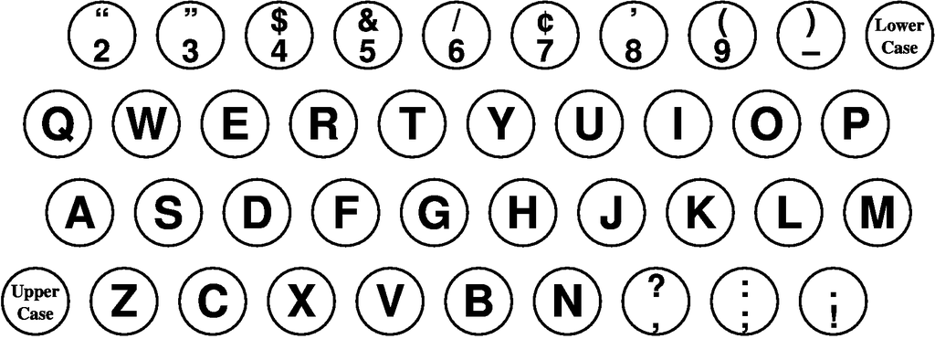

## But keyboards:

1936

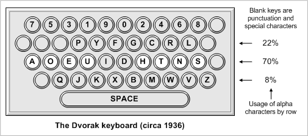

## Path Dependence:

Silly keyboard due to time-specific tech problem \(\xrightarrow{}\)

Lots of firms buy silly keyboard \(\xrightarrow{}\)

Lots of typists learn silly keyboard \(\xrightarrow{}\)

NEW, BETTER KEYBOARD (1936)

\(\xrightarrow{}\) Still sensible for firms to buy silly keyboard

\(\xrightarrow{}\) Still more sensible for typists to learn silly typing

\(\xrightarrow{}\) Stuck with silly keyboard

## Path Dependence:

Contribution pension system started (pay in $, get out $)

\(\xrightarrow{}\) Workers pay in contributions

\(\xrightarrow{}\) Workers accumulate "earned"/entitlement benefits

\(\xrightarrow{}\) Workers save less privately for retirement

\(\xrightarrow{}\) Cutting pension benefits is politically risky

\(\xrightarrow{}\) Pension system intact, even with conservative government

## Path Dependence

Policy implemented, institution created, product introduced

\(\xrightarrow{}\) Actors use and adapt to policy, institution, product

\(\xrightarrow{}\) Given adaptation, less costly to stick with status quo than change

\(\xrightarrow{}\) Stability of original arrangement in face of challenges, better options

**Self-reinforcing** logic over time.

## Economic perceptions:

Huh?

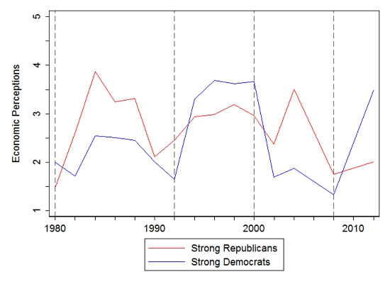

## Economic perceptions:

### Citizens have values

\(\xrightarrow{}\) Citizens chose party based on values

\(\xrightarrow{}\) Citizens gather information that supports party choice/values

\(\xrightarrow{}\) Perceptions of reality determined by partisanship

## Motivated Reasoning

People gather information for some reason

- One reason could be accuracy
- One reason could be for **pleasure** of having worldview **validated**

If people are emotionally attached to beliefs

- it feels good to be told your beliefs are right
- search for information or believe information that **reinforce their beliefs**
- **more information** makes motivated reasoning **worse**

## Motivated Reasoning helps explain:

- Why partisans are far apart on many issues (e.g. Democrats and Republicans in the US)
- Why Trump still has supporters, despite scandal
- Why US entered unwinnable war in Vietnam

## Why causal logics matter

## Why do we need to spell out causal logic?

Why isn't the validity of a simple causal claim enough?

## Competing Causal Logics

Wealthy countries are less likely to experience civil war. Why?

### Three different logics

1. Wealth \(\xrightarrow{}\) Larger defense budget \(\xrightarrow{}\) Rivals deterred \(\xrightarrow{}\) Less civil war
2. Wealth \(\xrightarrow{}\) Higher standard of living \(\xrightarrow{}\) Fewer grievances \(\xrightarrow{}\) Weak support for change \(\xrightarrow{}\) Less civil war
3. Wealth \(\xrightarrow{}\) Lots of job opportunities \(\xrightarrow{}\) Fewer listless young men \(\xrightarrow{}\) Fewer rebel recruits \(\xrightarrow{}\) Less civil war

## If you were a rebel…

### What would you do if…

… (1) were true?

- Undercut tax revenue? Target economic productivity?

… (2) were true?

- propaganda?

… (3) were true?

- Attempt to shut down major employment areas?

## If you were a government…

### What would you do if…

… (1) were true?

- Improve tax collection, spend more on security forces?

… (2) were true?

- Distribute existing wealth better, provide services, propaganda?

… (3) were true?

- Create a jobs program (keep people busy)?

## Causal logics matter because:

### They tell us *how* a cause creates an effect

- this can help refine the **scope** (generality) of the causal claim

### They suggest *other* causes

- If \(C \xrightarrow{} e_1 \xrightarrow{} e_2 \xrightarrow{} e_3 \xrightarrow{} E\)
- We can find a \(D\) that also affects \(e_1, e_2, \dots\)

### They improve prescriptive claims

- We can't change \(C\)
- We **can** change \(e_1\) or \(e_2\), etc.
- Policies require specifics: causal logics give us more specifics on **how**